# Exploring Daily Caffeine Consumption Patterns

## Why try to track caffeine intake?

Caffeine is part of my daily routines and is often used to improve focus, maintain energy, or stay productive throughout the day. To better understand these habits, I collected data about caffeine consumption, including the type of drink consumed, the time of day, reasons for drinking caffeine, focus levels, and sleep quality before taking the caffeinated drinks.

The visual story explores how caffeine consumption changes throughout the day and how it may relate to productivity.

## Caffeine Consumption Peaks During Active Hours

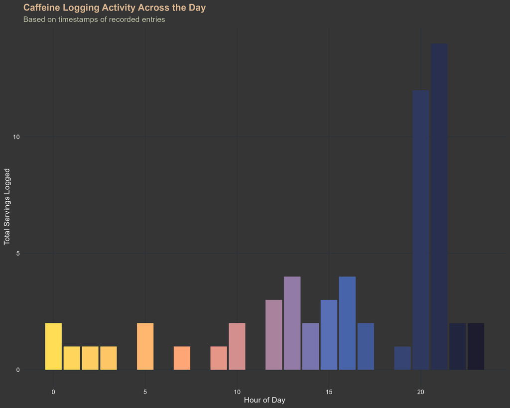

Bar chart showing total caffeine servings logged across different hours of the day.

The bar chart shows caffeine logging activity occurring throughout the day, with a noticeably higher volume of entries during the evening, particularly around 8 pm. This may suggest that many people consume their final caffeinated drink during the afternoon or evening, making it easier to record their total caffeine intake by the end of the night or certain periods where no further caffeine was consumed.

## Reasons for Each Caffeine Consumption

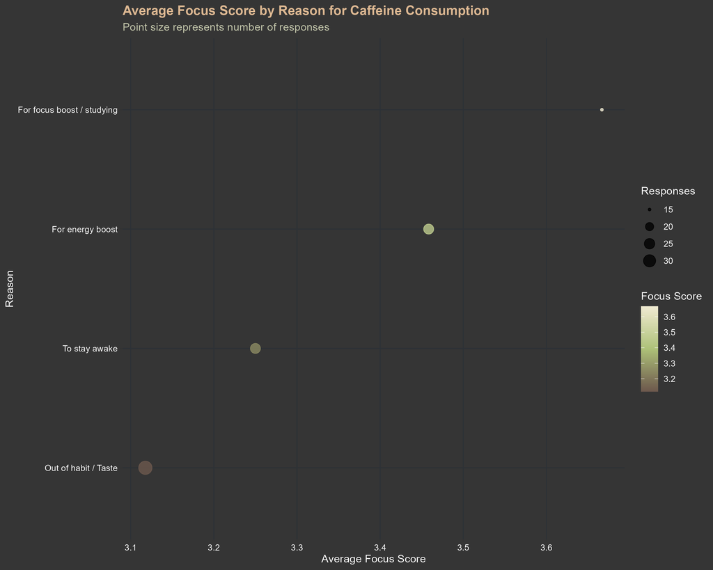

The point plot shows the relationship between the average focus score and the reasons respondents consumed caffeine. Using average focus scores makes the visualisation easier to interpret and allows clearer comparisons between different motivations for caffeine consumption.

Based on the graph, “Out of habit/Taste” was one of the most common reasons for consuming caffeine, as shown by the larger point size. However, this category had one of the lowest average focus scores. In contrast, “For focus boost/Studying” had fewer responses but showed the highest average focus score. This pattern is understandable, as people who consume caffeine specifically for studying or improving focus may expect caffeine to increase their concentration and alertness. This expectation could also contribute to a placebo effect, where respondents perceive themselves as being more focused after consumption.

It is also important to note that respondents were allowed to select multiple reasons in the Google Form. This may explain why “Out of habit/Taste” appeared more frequently across responses. Despite this, the graph still shows that respondents who consumed caffeine for studying or focus-related reasons reported higher average focus scores overall.

## Caffeine Intake Across the Day

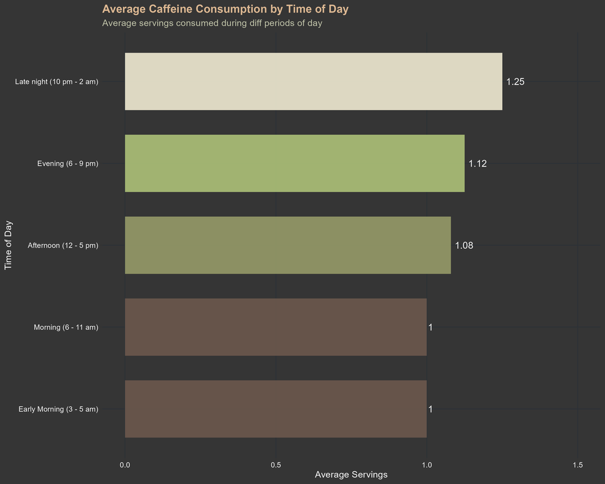

Horizontal bar chart displaying average caffeine servings consumed during different times of the day.

The horizontal bar chart shows the average number of caffeine servings consumed during different times of the day. Using averages makes it easier to compare consumption patterns across each time period and identify when caffeine intake tends to be higher. The graph shows that caffeine consumption varied throughout the day, with some time periods recording noticeably higher average servings than others. This may reflect differences in energy levels, work or study demands, and daily routines during certain parts of the day.

Higher average servings during later periods of the day may suggest that some respondents relied on caffeine to maintain focus or productivity as the day progressed. In contrast, lower average servings during other periods may indicate reduced caffeine use when respondents felt less need for additional energy. Overall, the graph demonstrates that caffeine consumption patterns are not consistent throughout the day and are likely influenced by personal habits and lifestyle routines.

## Average Caffeine Consumption by Sleep Quality

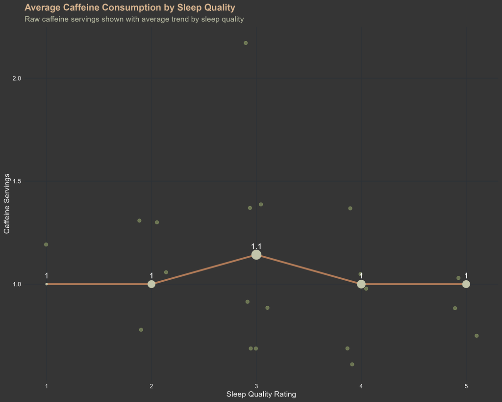

Line and point plot showing average caffeine servings consumed across different sleep quality ratings.

The jitter, line, and point plot shows the relationship between sleep quality and caffeine consumption. The scattered points represent the raw data of individual caffeine servings, while the connected points and line show the average servings for each sleep quality rating. This makes it easier to compare both the variation in responses and the overall trend.

One possible explanation is that respondents with average sleep quality (rating of 3) may rely more heavily on caffeine to maintain energy and focus throughout the day. In contrast, respondents with very good sleep quality may feel less need for caffeine, while those with poorer sleep quality may limit their caffeine intake for health, sleep, or personal reasons. Although the graph does not prove a direct relationship between sleep quality and caffeine consumption, it highlights how caffeine habits may vary depending on individuals’ perceptions of their sleep and energy levels.

## Final Observation

Overall, the visualisations reveal that caffeine consumption is closely connected to daily routines and productivity. Logging activity throughout the day suggests that caffeine is commonly consumed during active periods when respondents may need additional energy or alertness. The data also shows that focus and studying were strongly associated with higher reported focus scores, highlighting caffeine’s role as a tool for concentration and productivity rather than simply a habitual drink. At the same time, differences in average caffeine consumption across times of the day suggest that caffeine habits are influenced by changing energy levels and daily responsibilities. The relationship between sleep quality and caffeine consumption further demonstrates that caffeine habits are not always straightforward. Respondents with moderate sleep quality reported the highest average caffeine intake, suggesting that individuals may use caffeine differently depending on how they perceive their energy levels and sleep patterns.

These visualisations show that caffeine consumption is shaped by a combination of habit, productivity needs, and lifestyle routines. Tracking this data provided a better understanding for me on how everyday caffeine habits may influence both focus and sleep throughout daily life.